# Thema 7 · Steekproevenverdeling & betrouwbaarheidsinterval

Deel 4 — Van steekproef naar populatie · *de bordjes*

# Van één egel naar een hele steekproef

Tot nu toe keken we naar de score van één egel. Nu nemen we een hele **steekproef** — zeg 25 egels — en kijken naar hun **gemiddelde**. Want in de praktijk zien we de populatie nooit; we hebben alleen een steekproef, en daarmee willen we iets zeggen over alle egels. Dit is de stap naar **inferentie**: van steekproef naar populatie.

**OpmerkingDe egels — pienterheid, nu in steekproeven**

De pienterheid is normaal verdeeld met $\mu_x = 100$ en $\sigma_x = 15$ (thema 3). We trekken steekproeven van $n = 25$ egels en kijken naar het steekproefgemiddelde $\bar{x}$.

# Drie verdelingen — niet door elkaar halen

Die derde is de nieuwe, en de belangrijkste.

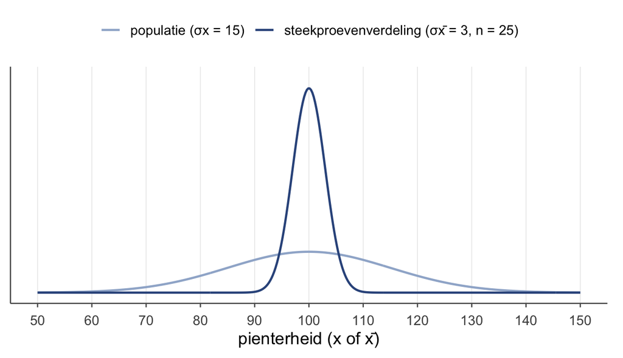

Figuur 1: Twee curves overlapt: de brede populatieverdeling van pienterheid (lichtblauw, σx = 15) en de smalle steekproevenverdeling van het steekproefgemiddelde x̄ bij n = 25 (donkerblauw, σx̄ = 3). Beide hebben centrum 100. De bordjes liggen veel dichter bij elkaar dan individuele egels — dat is wat de standaardfout vangt.

# De bordjes — het spelletje, opnieuw

Herinner je het spelletje uit thema 1 (er komt iets binnen, wat is je beste gok?). Nu schalen we het op:

> Jullie nemen állemaal een steekproef van 25 egels, rekenen het gemiddelde uit, schrijven dat op een **bordje**, en hangen het op. Ik kom langs en gok wat erop staat. Mijn beste gok: 100 (het populatiegemiddelde). Maar het ene bordje zegt 103, het andere 97 — ze wijken af.

Vroeger (thema 1) vroegen we: hoeveel mist één *egel* het gemiddelde? Nu vragen we: hoeveel mist één *bordje* (één steekproefgemiddelde) het echte gemiddelde? Die afwijking van een bordje is weer een gokfout. En de **gemiddelde** gokfout van een bordje is de **standaardafwijking van het steekproefgemiddelde** — die noemen we de **standaardfout**, $\sigma_{\bar{x}}$.

**TipIndividuen variëren met σ, statistieken met de standaardfout**

Eén egel wijkt af met $\sigma_x$. Eén bórdje (een steekproefgemiddelde) wijkt af met $\sigma_{\bar{x}}$ — en dat is kleiner, want een gemiddelde “middelt de uitschieters weg”. Het is nog steeds gewoon een standaardafwijking (de gemiddelde gokfout) — alleen van een ander soort gebeurtenis: niet een individu, maar een steekproefuitkomst.

# De standaardfout

$$\sigma_{\bar{x}} = \frac{\sigma_x}{\sqrt{n}} = \frac{15}{\sqrt{25}} = \frac{15}{5} = 3$$

(Herinner je uit thema 4: een variantie schaalt met het kwadraat van een factor. Een gemiddelde is een gewogen optelling; daar valt de $\sqrt{n}$ uit — dáárom $\sqrt{n}$.) Speel met $n$ en je ziet de theorie:

| $n$ | $\sigma_{\bar{x}} = 15/\sqrt{n}$ |
| --- | --- |
| 9 | 5 |
| 25 | 3 |
| 100 | 1,5 |

Hoe groter de steekproef, hoe **dichter de bordjes bij elkaar** liggen — hoe preciezer je schatting.

**TipCentrale limietstelling — waarom we de z-tabel mogen gebruiken**

Het bijzondere (en eigenlijk flauwe): als je steekproef groot genoeg is (vuistregel $n \gtrsim 15$), dan is de **steekproevenverdeling bij benadering normaal** — hoe lelijk of scheef de populatie ook is. Daarom mogen we voor $\bar{x}$ gewoon de z-tabel pakken. Let op het woordje *bij benadering*: bij een lelijke, scheve populatie is de steekproevenverdeling niet magisch perfect normaal, maar bij genoeg egels vaak dichtbij genoeg om ermee te rekenen.

# Het betrouwbaarheidsinterval

We vonden in onze enige echte steekproef $\bar{x} = 106$. Dat is onze **puntschatting** van $\mu_x$. Maar één getal is te stellig — we geven een **range** eromheen waarvan we redelijk zeker zijn dat de ware $\mu_x$ erin ligt:

$$\bar{x} \pm z^* \cdot \sigma_{\bar{x}}$$

Voor 95% zekerheid is $z^* = 1{,}96$ (de heilige z-waarde). Dus:

$$106 \pm 1{,}96 \cdot 3 = 106 \pm 5{,}88 = [\,100{,}12\,;\,111{,}88\,]$$

Dat stuk dat je naar links én rechts gaat, $M = z^* \cdot \sigma_{\bar{x}} = 5{,}88$, heet de **foutenmarge** (de halve breedte). De $z^*$-waarden uit je hoofd: 90% → 1,645; 95% → 1,96; 99% → 2,576.

**TipWelke kant op? p → z → x (lineaaltje = σ_x̄)**

Een betrouwbaarheidsinterval is gewoon de richtings-engine uit thema 3, maar nu met de **standaardfout als lineaaltje**. Je krijgt een kans (het CI-niveau) en zoekt een gebeurtenis (de grenzen): dus $p \to z \to x$. Het fietsje vertrekt nu vanuit $\bar{x}$, met snelheid $\sigma_{\bar{x}}$, en je wandelt $z^*$ lineaaltjes naar links en naar rechts.

**OpmerkingWat betekent ‘95%’ precies? (het hoefijzer)**

Strikt genomen: als je dit spelletje 100 keer zou doen — 100 keer een steekproef nemen en een 95%-interval berekenen — dan bevat in 95 van die 100 gevallen het interval de ware $\mu_x$. (Als een hoefijzer dat je 100 keer naar de paal gooit en 95 keer raak.) De “gezellige” lezing — *met 95% zekerheid ligt $\mu_x$ tussen 100,12 en 111,88* — mag je voelen, maar weet dat de strikte versie over de **intervallen** gaat, niet over deze ene.

# Foutenmarge en steekproefgrootte

De foutenmarge hangt af van $n$: meer egels → kleinere $M$. Andersom kun je vooraf uitrekenen hoeveel egels je nodig hebt voor een gewenste precisie. Wil je $M \le 2$ bij 95% ($\sigma_x = 15$)?

$$n = \left(\frac{z^* \cdot \sigma_x}{M}\right)^2 = \left(\frac{1{,}96 \cdot 15}{2}\right)^2 = 14{,}7^2 = 216{,}09 \;\to\; 217$$

(Naar **boven** afronden — met 216 zit je nog net boven de grens; meer egels = kleinere marge.)

# Oefenen

**OpmerkingT7.1 — Standaardfout en n**

De pienterheid heeft $\sigma_x = 15$.

1. Wat is de standaardfout bij $n = 9$? En bij $n = 100$?
2. Waarom wordt het interval smaller als $n$ groter wordt?

**OpgeletAntwoord T7.1**

**(a)** $\sigma_{\bar{x}} = 15/\sqrt{9} = 5$; en $15/\sqrt{100} = 1{,}5$.

**(b)** Een groter $n$ middelt de uitschieters sterker weg, dus de bordjes (steekproefgemiddelden) liggen dichter bij elkaar → kleinere $\sigma_{\bar{x}}$ → kleinere foutenmarge $z^*\sigma_{\bar{x}}$ → smaller interval. Meer informatie, preciezere schatting.

**OpmerkingT7.2 — Een interval bouwen**

Een steekproef van $n = 9$ egels geeft $\bar{x} = 108$ ($\sigma_x = 15$). Bouw het 95%-betrouwbaarheidsinterval voor $\mu_x$. Ligt 100 erin?

**OpgeletAntwoord T7.2**

$\sigma_{\bar{x}} = 15/\sqrt{9} = 5$. Foutenmarge $M = 1{,}96 \cdot 5 = 9{,}8$. Interval: $108 \pm 9{,}8 = [\,98{,}2\,;\,117{,}8\,]$. Wandel je van links naar rechts, dan kom je 100 tegen — dus **ja, 100 ligt erin**. (In thema 8 zie je: dat betekent dat we bij een toets H₀: $\mu_x = 100$ niet zouden verwerpen.)

# Wat blijft liggen

Hier gebruiken we $\sigma_x$ alsof we ’m kennen. In de echte wereld ken je de populatie-standaardafwijking nooit (alleen God) — dan schat je ’m met $s_x$ uit de steekproef, wordt het lineaaltje de standaardfout $s_x/\sqrt{n}$, en gebruik je de $t$-verdeling in plaats van $z$. Dat komt in thema 9. En in thema 8 draaien we de vraag om: niet “wat is $\mu_x$?”, maar “ís $\mu_x$ gelijk aan een bepaalde waarde?” — dan toetsen we.

# Tot slot

Drie verdelingen, één nieuw beeld: de bordjes. De standaardfout is de spreiding van die bordjes, $\sigma_x/\sqrt{n}$, en daarmee bouw je een betrouwbaarheidsinterval rond je schatting. Het is nog steeds de richtings-engine — alleen wandelt het fietsje nu met de standaardfout als lineaaltje. In het volgende deel gaan we toetsen.

*Werkboek OZP 1 · Thema 7, versie 0.1 (handrekenen & theorie; SPSS later). Doorlopend voorbeeld: de egels.*

Terug naar boven